# GABA-AD: Interaction of SICI and pharmacological GABAAR activation

## **STUDY DESCRIPTION**

### Aim and hypothesis

The project aims to identify specific changes in our primary outcome measures (TMS-evoked potentials, TEPs) following the pre-activation of local network of cortical interneurons using a paired-pulse TMS protocol. The conditioning time (CS) of a sub-threshold intensity (80%rMT) his used to depolarize the low-threshold inhibitory interneuron at the site of the stimulation, which leads to a decrease in cortical excitability and a weaker response to the subsequent testing time (TS). This phenomenon is called the Short-latency IntraCortical Inhibition (SICI) and was originally measured in motor evoked potentials.

However, we can measure brain’s reaction to TMS more directly with TEPs, and we expect to see changes that will correspond to the increased local GABAA neurotransmission. The size of this effect can be then used to assess the efficiency of the system specifically at the site of stimulation.

### Experimental design

20 subjects participated in 2 experimental sessions. Each session the same measures were taken at the baseline and after medication with either alprazolam (an allosteric BDZ agonist of GABAARs) or placebo.

The question we aim to answer with our data are as follow: Does the global activation of GABAARs with alprazolam affect the extent of SICI?

### Outcome variables

- **SICI**: calculated as the change of the SICI of each component (simple subtraction) following the piared-pulse stimulation as compared to the simple TS –> this measure serves to evaluate the effect of medication on SICI

### Fixed effect

- **TIME**
  0. baseline
  1. post-medication
- **MEDICATION**
  0. placebo = control condition
  1. amplrazolam
- Covariate: **rMT change** - continuous value

### Random effect

- random intercept for each **SUBJECT**

**Following pipeline treats each outcome measure separately, as an independent measure.**

## **STATISTICAL ANALYSIS: BASELINE SICI**

### Import data

Choose a .csv file with either TEP or rsEEG data.

```r
# import the data
input_file <- choose.files(default = folder_dir, caption = "Select the dataset")
data_all <- as_tibble(read.csv(input_file))
names(data_all)
```

```
[1] "subject"    "medication" "time"       "peak"       "SICI"       "SICI_MEP"   "rMT"
```

```r
summary(data_all)
```

```
    subject       medication            time               peak                SICI            SICI_MEP           rMT
 Min.   : 1.00   Length:480         Length:480         Length:480         Min.   :-18.714   Min.   :  2.83   Min.   :38.0
 1st Qu.: 5.75   Class :character   Class :character   Class :character   1st Qu.: -1.879   1st Qu.:  9.45   1st Qu.:45.0
 Median :10.50   Mode  :character   Mode  :character   Mode  :character   Median : -0.548   Median : 20.61   Median :48.5
 Mean   :10.50                                                            Mean   : -1.033   Mean   : 26.42   Mean   :49.8
 3rd Qu.:15.25                                                            3rd Qu.:  0.371   3rd Qu.: 35.94   3rd Qu.:54.2
 Max.   :20.00                                                            Max.   :  3.970   Max.   :114.57   Max.   :65.0
```

### Variable of interest

```r
# variable characteristics
target_peak <- 'N17'

# subset data
data <- data_all %>%
  filter(peak == target_peak) %>%
  mutate(subject = factor(subject)) %>%
  mutate(medication = factor(medication, levels=c('placebo', 'alprazolam'), ordered = TRUE)) %>%
  mutate(time = factor(time, levels=c('pre', 'post'), ordered = TRUE)) %>%
  # select(subject, medication, time, SICI, rMT)
  select(subject, medication, time, SICI_MEP, rMT) %>%
  mutate(SICI = SICI_MEP)
str(data)
```

```
tibble[,6] [80 x 6] (S3: tbl_df/tbl/data.frame)
 $ subject   : Factor w/ 20 levels "1","2","3","4",..: 1 1 1 1 2 2 2 2 3 3 ...
 $ medication: Ord.factor w/ 2 levels "placebo"<"alprazolam": 1 1 2 2 1 1 2 2 1 1 ...
 $ time      : Ord.factor w/ 2 levels "pre"<"post": 1 2 1 2 1 2 1 2 1 2 ...
 $ SICI_MEP  : num [1:80] 20.82 25.49 26.82 43.88 3.96 ...
 $ rMT       : int [1:80] 43 43 43 38 55 53 56 58 60 62 ...
 $ SICI      : num [1:80] 20.82 25.49 26.82 43.88 3.96 ...
```

### Descriptive statistics

The distribution is described and visualized for both levels of the factor ‘medication’ separately. The normality is checked both visually (histogram, QQ-plot) and using the Shapiro-Wilk normality test.

```r
# ---- DISTRIBUTION ----
# get summary per medication
data %>%
  select(c(medication, time, SICI)) %>%
  group_by(medication, time) %>%
  skim()
```

```
-- Data Summary ------------------------
                           Values
Name                       Piped data
Number of rows             80
Number of columns          3
_______________________
Column type frequency:
  numeric                  1
________________________
Group variables            medication, time

-- Variable type: numeric -----------------------------------------------------------------------------------------------------
# A tibble: 4 x 13
  skim_variable medication time  n_missing complete_rate  mean    sd    p0   p25   p50   p75  p100 hist
* <chr>         <ord>      <ord>     <int>         <dbl> <dbl> <dbl> <dbl> <dbl> <dbl> <dbl> <dbl> <chr>
1 SICI          placebo    pre           0             1  25.1  23.3  3.10  7.80  20.3  31.4  95.2 ▇▂▁▁▁
2 SICI          placebo    post          0             1  26.7  17.8  4.36 13.9   26.4  35.6  77.1 ▇▇▃▂▁
3 SICI          alprazolam pre           0             1  24.8  24.6  2.83  9.51  17.7  30.9 115.  ▇▃▁▁▁
4 SICI          alprazolam post          0             1  29.1  20.6  6.62  9.19  28.1  44.3  78.9 ▇▂▆▁▁
```

```r
# calculate mean values
data_mean <- data %>%
  group_by(medication, time) %>%
  summarise(mean = mean(SICI), sd = sd(SICI), sem = sd(SICI)/sqrt(20), median = median(SICI))
data_mean %>%
  knitr::kable()
```

| medication | time | mean | sd | sem | median |
| --- | --- | --- | --- | --- | --- |
| placebo | pre | 25.06 | 23.26 | 5.202 | 20.29 |
| placebo | post | 26.75 | 17.77 | 3.974 | 26.36 |
| alprazolam | pre | 24.79 | 24.62 | 5.506 | 17.74 |
| alprazolam | post | 29.07 | 20.56 | 4.598 | 28.06 |

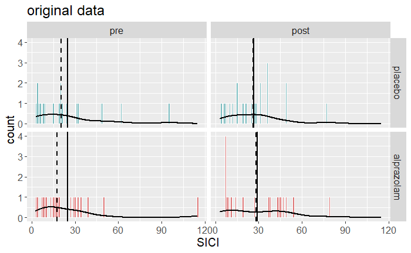

```r
# plot the distribution
data %>%
  ggplot(aes(x = SICI, y = ..count.., fill = medication)) +
  geom_histogram(binwidth = 1, col = 'white', alpha = 0.5) +
  geom_density(alpha = 0, size = 1) +
  facet_grid(medication ~ time) +
  geom_vline(data = data_mean, aes(xintercept = median), linetype = 'dashed', size = 1) +
  geom_vline(data = data_mean, aes(xintercept = mean), size = 1) +
  ggtitle('original data') +
  ylab('count') +
  xlab('SICI') +
  theme(text = element_text(size = 15), legend.position = 'none') +
  scale_fill_manual(values = col_palette[c(2, 4)])
```

```r
# skewness and kurtosis
data_shape <- data %>%
  group_by(medication, time) %>%
  summarise(skewness = skewness(SICI), kurtosis = kurtosis(SICI))
data_shape %>%
  knitr::kable()
```

| medication | time | skewness | kurtosis |
| --- | --- | --- | --- |
| placebo | pre | 1.5739 | 5.248 |
| placebo | post | 1.0766 | 4.269 |
| alprazolam | pre | 2.5452 | 9.976 |
| alprazolam | post | 0.5847 | 2.603 |

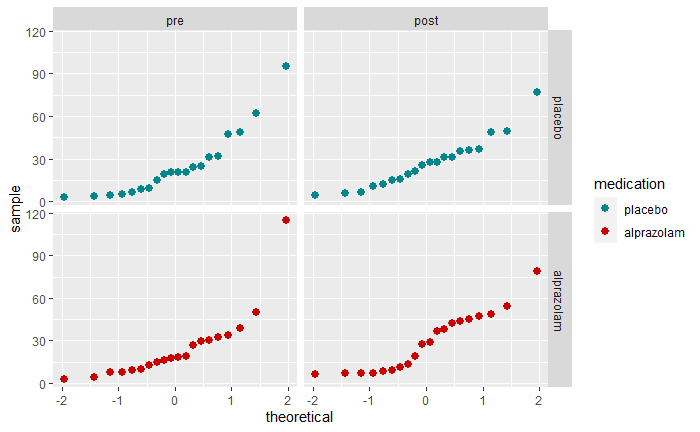

```r
# ---- NORMALITY TEST ----
# QQ-plot
data %>%
  ggplot(aes(sample = SICI, col = medication)) +
  geom_qq(size = 2.5) +
  facet_grid(medication ~ time) +
  scale_color_manual(values = col_palette[c(2, 4)])
```

```r
# Shapiro-Wilk test
data %>%
  group_by(medication, time) %>%
  shapiro_test(SICI)
```

| medication | time | variable | statistic | p |
| --- | --- | --- | --- | --- |
| placebo | pre | SICI | 0.8263 | 2.195e-03 |
| placebo | post | SICI | 0.9148 | 7.866e-02 |
| alprazolam | pre | SICI | 0.7108 | 5.296e-05 |
| alprazolam | post | SICI | 0.8942 | 3.211e-02 |

```r
NA
```

### Data transformation

Transformations are applied only when needed - in the case of a non-normal distribution. The code below tests two possible transformations - square root and log transform with the base 2 - and their effect on the final distribution.

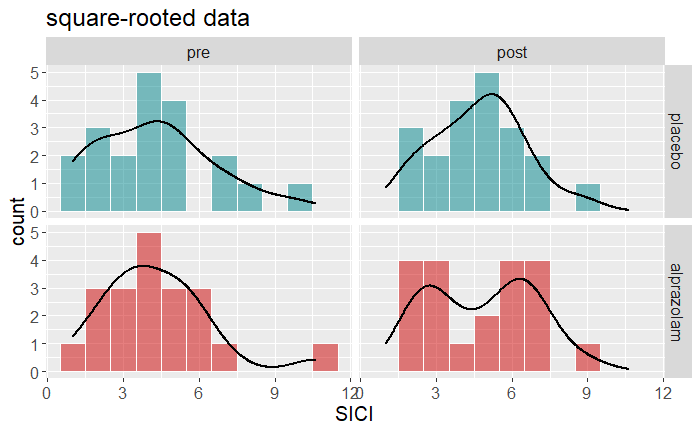

```r
# constants --> onset to positive values
c <- -min(data$SICI) + 1
data_trans <- data %>%
  # filter(!(subject %in% remove_subj)) %>%
  mutate(SICI = SICI + c)

# reflect if negatively skewed
# data_trans <- data_trans %>%
#   group_by(time, medication) %>%
#   mutate(SICI = max(data_trans$SICI) - SICI + 1)

# ---- SQUARE ROOT ----
# create new variable
data_trans <- data_trans %>%
  mutate(SICI_sqrt = sqrt(SICI))

# plot by mediation
data_trans %>%
  ggplot(aes(x = SICI_sqrt, y = ..count.., fill = medication)) +
  geom_histogram(binwidth = 1, col = 'white', alpha = 0.5) +
  geom_density(alpha = 0, size = 1) +
  facet_grid(medication ~ time) +
  ggtitle('square-rooted data') +
  ylab('count') +
  xlab('SICI') +
  theme(text = element_text(size = 15), legend.position = 'none') +
  scale_fill_manual(values = col_palette[c(2, 4)])
```

```r
# Shapiro-Wilk test
data_trans %>%
  group_by(medication, time) %>%
  shapiro_test(SICI_sqrt)
```

| medication | time | variable | statistic | p |
| --- | --- | --- | --- | --- |
| placebo | pre | SICI_sqrt | 0.9494 | 0.35834 |
| placebo | post | SICI_sqrt | 0.9786 | 0.91478 |
| alprazolam | pre | SICI_sqrt | 0.9249 | 0.12312 |
| alprazolam | post | SICI_sqrt | 0.9047 | 0.05055 |

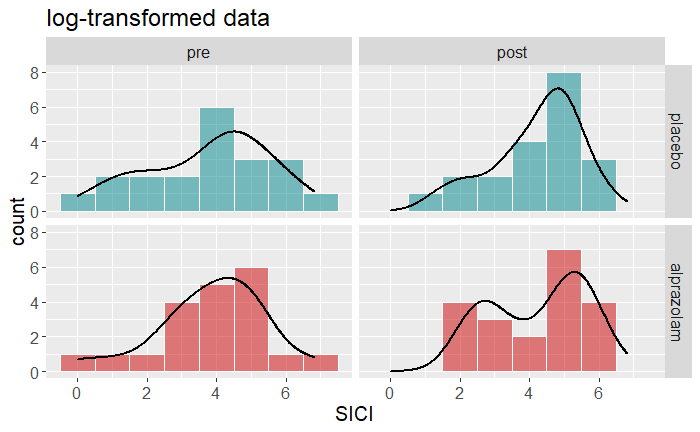

```r
# ---- LOG TRANSFORM ----
# create new variable
data_trans <- data_trans %>%
  mutate(SICI_log2 = log2(SICI))

# plot by mediation
data_trans %>%
  ggplot(aes(x = SICI_log2, y = ..count.., fill = medication)) +
  geom_histogram(binwidth = 1, col = 'white', alpha = 0.5) +
  geom_density(alpha = 0, size = 1) +
  facet_grid(medication ~ time) +
  ggtitle('log-transformed data') +
  ylab('count') +
  xlab('SICI') +
  theme(text = element_text(size = 15), legend.position = 'none') +
  scale_fill_manual(values = col_palette[c(2, 4)])
```

```r
# Shapiro-Wilk test
data_trans %>%
  group_by(medication, time) %>%
  shapiro_test(SICI_log2)
```

| medication | time | variable | statistic | p |
| --- | --- | --- | --- | --- |
| placebo | pre | SICI_log2 | 0.9517 | 0.39424 |
| placebo | post | SICI_log2 | 0.9415 | 0.25570 |
| alprazolam | pre | SICI_log2 | 0.9632 | 0.60932 |
| alprazolam | post | SICI_log2 | 0.8824 | 0.01955 |

### Outlier rejection

If a serious outlier is identified, the subject might be removed from the dataset. This step is an option if transformations don’t prove helpful.

```r
# outlier threshold
out_threshold <- data %>%
  group_by(medication, time) %>%
  summarize(a = quantile(SICI, 0.75) - 1.5*IQR(SICI), b = quantile(SICI, 0.75) + 1.5*IQR(SICI))
out_threshold %>%
  knitr::kable()
```

| medication | time | a | b |
| --- | --- | --- | --- |
| placebo | pre | -4.000 | 66.80 |
| placebo | post | 3.118 | 68.05 |
| alprazolam | pre | -1.168 | 62.92 |
| alprazolam | post | -8.353 | 96.89 |

```r
# idenntify outliers
outliers <- boxplot.stats(data %>% group_by(time, medication) %>% pull(SICI))$out
outliers_index <- which(data %>% group_by(time, medication) %>% pull(SICI) %in% c(outliers))
data[outliers_index,]
```

| subject | medication | time | SICI_MEP | rMT | SICI |
| --- | --- | --- | --- | --- | --- |
| 11 | placebo | pre | 95.24 | 55 | 95.24 |
| 11 | alprazolam | pre | 114.57 | 52 | 114.57 |
| 11 | alprazolam | post | 78.87 | 60 | 78.87 |
| 12 | placebo | post | 77.07 | 50 | 77.07 |

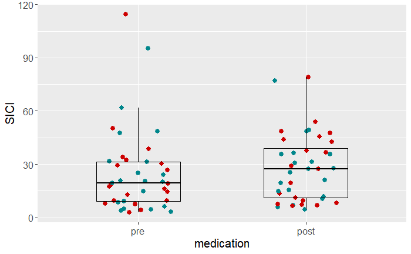

```r
# boxplot
data %>%
  ggplot(aes(time, SICI, col = medication)) +
  geom_jitter(width = 0.2, size = 2.5, show.legend = FALSE) +
  scale_color_manual(values = col_palette[c(2, 4)]) +
  geom_boxplot(col = 'black', alpha = 0, width = 0.5) +
  ylab('SICI') +
  xlab('medication') +
  theme(text = element_text(size = 15))
```

```r
# choose which outliers to remove
# remove_subj <- data$subject[outliers_index[c(1)]]
remove_subj <- 2

# ---- DISTRIBUTION ----
# get summary per medication
data_filt <- data %>%
  filter(!(subject %in% remove_subj)) %>%
  select(c(medication, time, SICI)) %>%
  group_by(medication, time)

# calculate mean values
data_mean <- data_filt %>%
  group_by(medication, time) %>%
  summarise(mean = mean(SICI), sd = sd(SICI), sem = sd(SICI)/sqrt(19), median = median(SICI))
data_mean %>%
  knitr::kable()
```

| medication | time | mean | sd | sem | median |
| --- | --- | --- | --- | --- | --- |
| placebo | pre | 26.17 | 23.35 | 5.357 | 20.39 |
| placebo | post | 27.85 | 17.55 | 4.025 | 27.22 |
| alprazolam | pre | 25.87 | 24.80 | 5.691 | 18.07 |
| alprazolam | post | 30.24 | 20.44 | 4.689 | 28.87 |

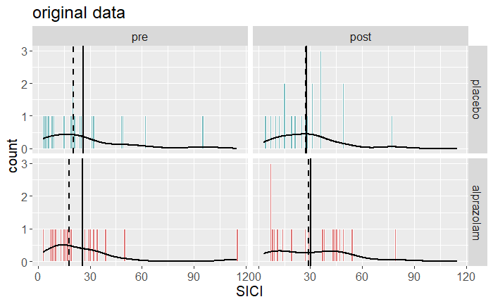

```r
# plot the distribution
data_filt %>%
  ggplot(aes(x = SICI, y = ..count.., fill = medication)) +
  geom_histogram(binwidth = 1, col = 'white', alpha = 0.5) +
  geom_density(alpha = 0, size = 1) +
  facet_grid(medication ~ time) +
  geom_vline(data = data_mean, aes(xintercept = median), linetype = 'dashed', size = 1) +
  geom_vline(data = data_mean, aes(xintercept = mean), size = 1) +
  ggtitle('original data') +
  ylab('count') +
  xlab('SICI') +
  theme(text = element_text(size = 15), legend.position = 'none') +
  scale_fill_manual(values = col_palette[c(2, 4)])
```

```r
# skewness and kurtosis
data_shape <- data_filt %>%
  group_by(medication, time) %>%
  summarise(skewness = skewness(SICI), kurtosis = kurtosis(SICI))
data_shape %>%
  knitr::kable()
```

| medication | time | skewness | kurtosis |
| --- | --- | --- | --- |
| placebo | pre | 1.5406 | 5.118 |
| placebo | post | 1.0855 | 4.333 |
| alprazolam | pre | 2.5297 | 9.761 |
| alprazolam | post | 0.5258 | 2.598 |

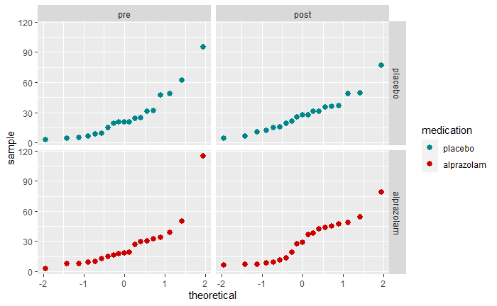

```r
# ---- NORMALITY TEST ----
# QQ-plot
data_filt %>%
  ggplot(aes(sample = SICI, col = medication)) +
  geom_qq(size = 2.5) +
  facet_grid(medication ~ time) +
  scale_color_manual(values = col_palette[c(2, 4)])
```

```r
# Shapiro-Wilk test
data_filt %>%
  group_by(medication, time) %>%
  shapiro_test(SICI)
```

| medication | time | variable | statistic | p |
| --- | --- | --- | --- | --- |
| placebo | pre | SICI | 0.8350 | 3.867e-03 |
| placebo | post | SICI | 0.9191 | 1.088e-01 |
| alprazolam | pre | SICI | 0.7087 | 7.067e-05 |
| alprazolam | post | SICI | 0.9077 | 6.716e-02 |

### Build models and compare

Based on the previous exploration, choose appropriate adjustment to the data.

```r
# choose transformation if necessary
trans <- readline(prompt = "Use transformation: ")
none
if(trans == 'sqrt'){
  data <- data %>%
    mutate(SICI_model = data_trans$SICI_sqrt)
}
if(trans == 'log'){
  data <- data %>%
  mutate(SICI_model = data_trans$SICI_log2)
}
if(trans == 'none'){
  data <- data %>%
  mutate(SICI_model = SICI)
}

# remove outliers if necessary
out <- askYesNo('Do you want to filter out ouliers?')
if(out){
  # data <- filter(data, !subject %in% remove_subj)
  data <- filter(data, !subject %in% 2)
}
```

Model n. 1: simple linear regression without random effects

```r
model_lm <- lm(SICI_model ~ time + medication + time*medication,
  data = data
)
summary(model_lm)
```

```
Call:
lm(formula = SICI_model ~ time + medication + time * medication,
    data = data)

Residuals:
   Min     1Q Median     3Q    Max
-23.62 -16.57  -4.16   7.94  88.70

Coefficients:
                    Estimate Std. Error t value Pr(>|t|)
(Intercept)           27.531      2.491   11.05   <2e-16 ***
time.L                 2.139      3.523    0.61     0.55
medication.L           0.739      3.523    0.21     0.83
time.L:medication.L    1.343      4.982    0.27     0.79
---
Signif. codes:  0 ‘***’ 0.001 ‘**’ 0.01 ‘*’ 0.05 ‘.’ 0.1 ‘ ’ 1

Residual standard error: 21.7 on 72 degrees of freedom
Multiple R-squared:  0.0067,    Adjusted R-squared:  -0.0347
F-statistic: 0.162 on 3 and 72 DF,  p-value: 0.922
```

```r
confint(model_lm)
```

```
                     2.5 % 97.5 %
(Intercept)         22.565 32.496
time.L              -4.883  9.161
medication.L        -6.283  7.761
time.L:medication.L -8.588 11.274
```

Model n. 2: empty model with random intercept

```r
model_ri <- lmer(
  SICI_model ~ 1 + (1|subject),
  data = data
)
summary(model_ri)
```

```
Linear mixed model fit by REML. t-tests use Satterthwaite's method ['lmerModLmerTest']
Formula: SICI_model ~ 1 + (1 | subject)
   Data: data

REML criterion at convergence: 619

Scaled residuals:
   Min     1Q Median     3Q    Max
-2.962 -0.561 -0.141  0.535  3.233

Random effects:
 Groups   Name        Variance Std.Dev.
 subject  (Intercept) 356      18.9
 Residual             114      10.7
Number of obs: 76, groups:  subject, 19

Fixed effects:
            Estimate Std. Error   df t value Pr(>|t|)
(Intercept)     27.5        4.5 18.0    6.12  8.9e-06 ***
---
Signif. codes:  0 ‘***’ 0.001 ‘**’ 0.01 ‘*’ 0.05 ‘.’ 0.1 ‘ ’ 1
```

```r
confint(model_ri)
```

```
Computing profile confidence intervals ...
```

```
             2.5 % 97.5 %
.sig01      13.274  26.72
.sigma       8.963  12.96
(Intercept) 18.493  36.57
```

Model n. 3: predictor variables + random intercept

```r
model_rip <- lmer(
  SICI_model ~ time + medication + time*medication + rMT + (1|subject),
  data = data
)
summary(model_rip)
```

```
Linear mixed model fit by REML. t-tests use Satterthwaite's method ['lmerModLmerTest']
Formula: SICI_model ~ time + medication + time * medication + rMT + (1 |      subject)
   Data: data

REML criterion at convergence: 601

Scaled residuals:
    Min      1Q  Median      3Q     Max
-3.0056 -0.5106 -0.0131  0.4304  2.9186

Random effects:
 Groups   Name        Variance Std.Dev.
 subject  (Intercept) 549.5    23.4
 Residual              92.2     9.6
Number of obs: 76, groups:  subject, 19

Fixed effects:
                    Estimate Std. Error      df t value Pr(>|t|)
(Intercept)          100.570     25.165  65.703    4.00  0.00017 ***
time.L                 2.634      1.566  48.950    1.68  0.09895 .
medication.L           1.783      1.596  50.431    1.12  0.26932
rMT                   -1.477      0.497  68.386   -2.97  0.00406 **
time.L:medication.L    2.198      2.221  49.167    0.99  0.32715
---
Signif. codes:  0 ‘***’ 0.001 ‘**’ 0.01 ‘*’ 0.05 ‘.’ 0.1 ‘ ’ 1

Correlation of Fixed Effects:
            (Intr) time.L mdct.L rMT
time.L       0.104
medicatin.L  0.215  0.023
rMT         -0.976 -0.106 -0.220
tm.L:mdct.L  0.126  0.014  0.028 -0.129
```

```r
confint(model_rip)
```

```
Computing profile confidence intervals ...
```

```
                      2.5 %   97.5 %
.sig01              15.7035  33.9945
.sigma               7.7496  11.4244
(Intercept)         43.4707 157.0337
time.L              -0.4235   5.6424
medication.L        -1.3811   4.8473
rMT                 -2.5909  -0.3364
time.L:medication.L -2.1501   6.4616
```

```r
anova(model_ri, model_rip)
```

```
refitting model(s) with ML (instead of REML)
```

```
Data: data
Models:
model_ri: SICI_model ~ 1 + (1 | subject)
model_rip: SICI_model ~ time + medication + time * medication + rMT + (1 |
model_rip:     subject)
          npar AIC BIC logLik deviance Chisq Df Pr(>Chisq)
model_ri     3 630 637   -312      624
model_rip    7 629 646   -308      615  8.49  4      0.075 .
---
Signif. codes:  0 ‘***’ 0.001 ‘**’ 0.01 ‘*’ 0.05 ‘.’ 0.1 ‘ ’ 1
```

Describe the full model using the nlme package in order to extract the p-value of the predictor.

```r
# choose the model to retain
model <- lme(
  SICI_model ~ time + medication + time*medication + rMT,
  random = ~ 1|subject,
  data = data,
  method = 'ML'
)

# fixed effects
broom.mixed::tidy(model, effects = 'fixed') %>%
  knitr::kable()
```

| term | estimate | std.error | df | statistic | p.value |
| --- | --- | --- | --- | --- | --- |
| (Intercept) | 100.305 | 25.1547 | 53 | 3.9875 | 0.0002 |
| time.L | 2.632 | 1.5676 | 53 | 1.6792 | 0.0990 |
| medication.L | 1.779 | 1.5978 | 53 | 1.1136 | 0.2705 |
| rMT | -1.472 | 0.4965 | 53 | -2.9641 | 0.0045 |
| time.L:medication.L | 2.195 | 2.2231 | 53 | 0.9874 | 0.3279 |

```r
# fixed effects
broom.mixed::tidy(model, effects = 'ran_pars') %>%
  knitr::kable()
```

| effect | group | term | estimate |
| --- | --- | --- | --- |
| ran_pars | subject | sd_(Intercept) | 22.588 |
| ran_pars | Residual | sd_Observation | 9.287 |

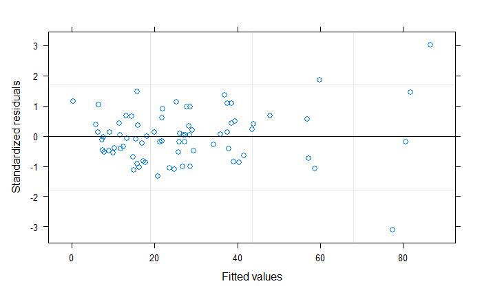

```r
# residuals
plot(model)
```

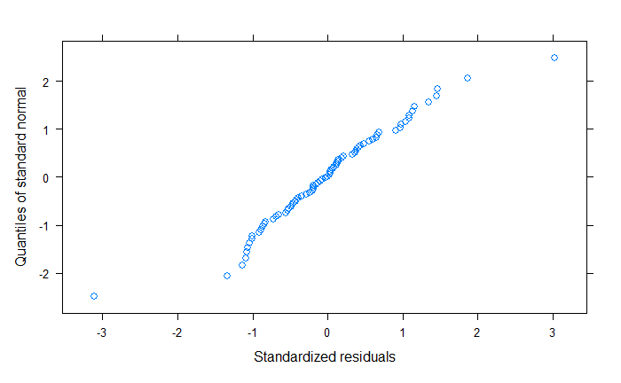

```r
qqnorm(model)
```

Estimate p values using the Kenward-Roger approximation

```r
anova(model_rip, ddf="Kenward-Roger") %>%
  knitr::kable()
```

|  | Sum Sq | Mean Sq | NumDF | DenDF | F value | Pr(>F) |
| --- | --- | --- | --- | --- | --- | --- |
| time | 260.51 | 260.51 | 1 | 53.49 | 2.8268 | 0.0985 |
| medication | 114.60 | 114.60 | 1 | 54.77 | 1.2435 | 0.2697 |
| rMT | 764.17 | 764.17 | 1 | 69.08 | 8.2920 | 0.0053 |
| time:medication | 90.17 | 90.17 | 1 | 53.68 | 0.9785 | 0.3270 |